# Events A-D

Andrew Stewart

04/03/2020

```r
library(tidyverse)
```

```r
tidy_data_filtered <- read_csv("tidy_data_filtered.csv")
```

```r
ID <- unique(tidy_data_filtered$ID)

seg <- c("Seg1", "Seg2", "Seg3", "Seg4", "Seg5", "Seg6", "Seg7", "Seg8", "Seg9",
         "Seg10", "EventA", "EventB", "EventC", "EventD", "Seg15", "Seg16", "Seg17",
         "Seg18", "Seg19", "Seg20", "EventE")

my_df <- expand_grid(ID, seg)

#my_df$press <- NA

music_data <- tidy_data_filtered %>%
  select(c(ID, music_training)) %>%
  distinct(ID, .keep_all = TRUE)

my_df <- left_join(my_df, music_data , by = "ID")

# set seg column to zero

tidy_data_filtered$seg <- "0"
```

For each of the events, I have plotted the histogram of clicks over time for the Event. I have also fitted the data to a gamma shaped distribution and plotted the fit. For each event, you can see the estimated parameters of the associated gamma distribution. Note that there is quite a variation both in terms of fit and in terms of parameter estimation.

## Event A

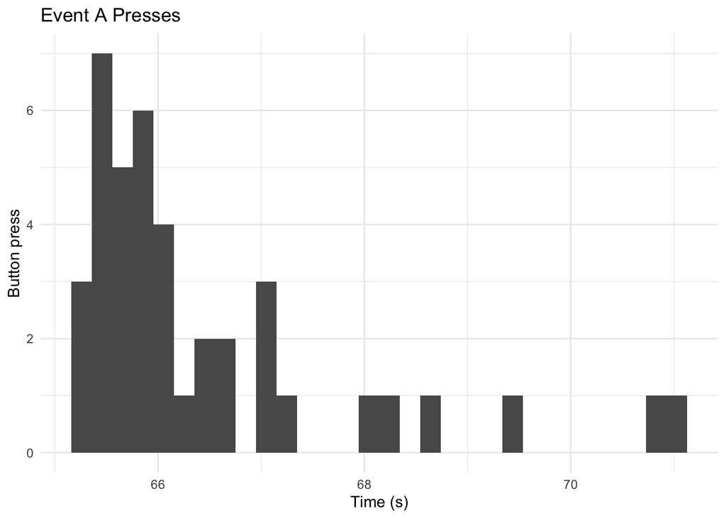

```r
Event_A <- tidy_data_filtered
Event_A[Event_A$time > 65.285 & Event_A$time < 71.286,]$seg <- "EventA"
Event_A$press <- 1

Event_A_joined_data <- left_join(my_df, select(Event_A,
                                       c("ID", "seg", "time", "press")), by = c("ID", "seg"))

Event_A_joined_data <- Event_A_joined_data %>%
  filter(seg == "EventA") %>%
  mutate(press = replace_na(press, 0))

Event_A %>%
  filter(seg == "EventA") %>%
  ggplot(aes(x = time)) +
  geom_histogram() +
  labs(title = "Event A Presses",
       x = "Time (s)",
       y = "Button press") +
  theme_minimal()
```

Let’s check the fit with the Gamma distribution and extract paaramenters using methods of moments estimation.

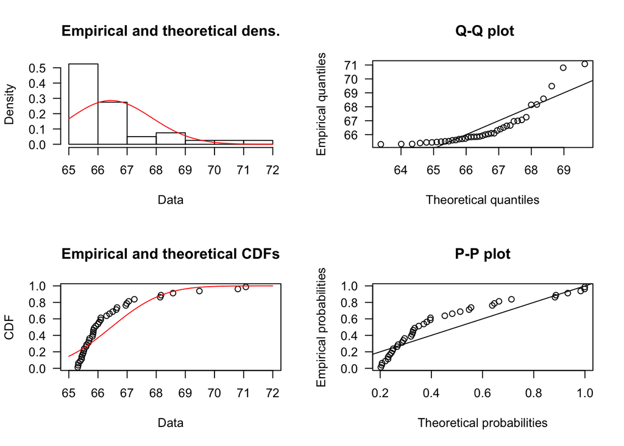

```r
plot(fitdistrplus::fitdist(filter(Event_A_joined_data, !is.na(time))$time, "gamma", method = "mme"), las = 1)
```

```r
summary(fitdistrplus::fitdist(filter(Event_A_joined_data, !is.na(time))$time, "gamma", method = "mme"), las = 1)
```

```
## Fitting of the distribution ' gamma ' by matching moments
## Parameters :
##         estimate
## shape 2266.47224
## rate    34.09712
## Loglikelihood:  -69.58774   AIC:  143.1755   BIC:  146.5532
```

## Event B

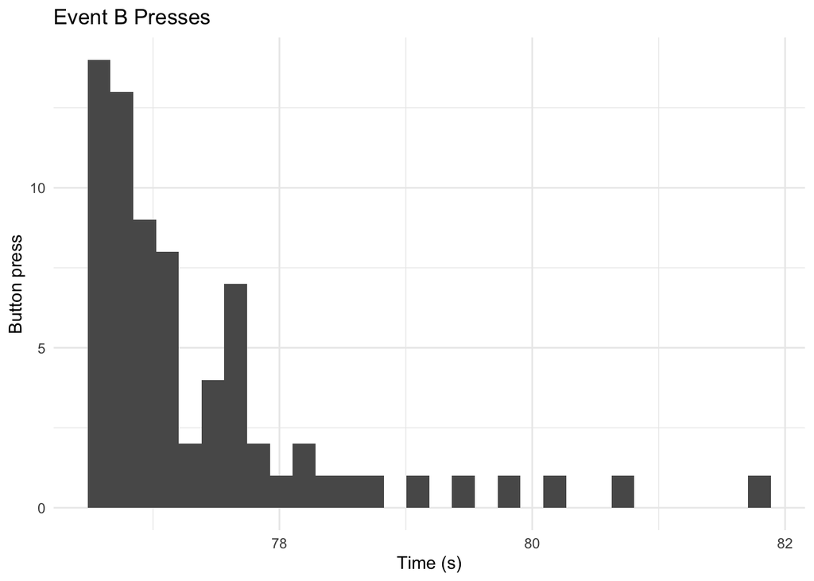

```r
Event_B <- tidy_data_filtered
Event_B[Event_B$time > 76.5 & Event_B$time < 82.51,]$seg <- "EventB"
Event_B$press <- 1

Event_B_joined_data <- left_join(my_df, select(Event_B,
                                               c("ID", "seg", "time", "press")), by = c("ID", "seg"))

Event_B_joined_data <- Event_B_joined_data %>%
  filter(seg == "EventB") %>%
  mutate(press = replace_na(press, 0))

Event_B %>%
  filter(seg == "EventB") %>%
  ggplot(aes(x = time)) +
  geom_histogram() +
  labs(title = "Event B Presses",
       x = "Time (s)",
       y = "Button press") +
  theme_minimal()
```

Let’s check the fit with the Gamma distribution and extract paaramenters using methods of moments estimation.

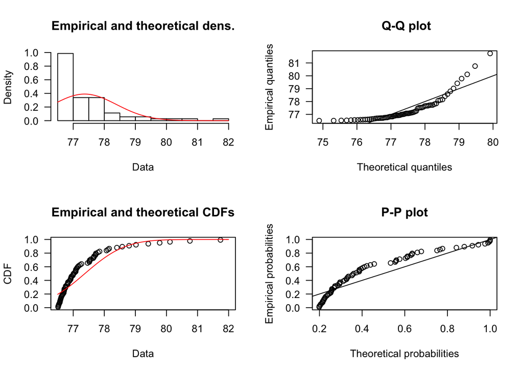

```r
plot(fitdistrplus::fitdist(filter(Event_B_joined_data, !is.na(time))$time, "gamma", method = "mme"), las = 1)
```

```r
summary(fitdistrplus::fitdist(filter(Event_B_joined_data, !is.na(time))$time, "gamma", method = "mme"), las = 1)
```

```
## Fitting of the distribution ' gamma ' by matching moments
## Parameters :
##        estimate
## shape 5721.4147
## rate    73.9396
## Loglikelihood:  -101.7026   AIC:  207.4051   BIC:  211.9305
```

## Event C

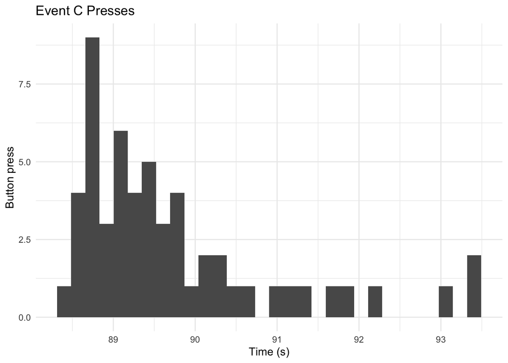

```r
Event_C <- tidy_data_filtered
Event_C[Event_C$time > 88.475 & Event_C$time < 94.476,]$seg <- "EventC"

Event_C$press <- 1

Event_C_joined_data <- left_join(my_df, select(Event_C,
                                               c("ID", "seg", "time", "press")), by = c("ID", "seg"))

Event_C_joined_data <- Event_C_joined_data %>%
  filter(seg == "EventC") %>%
  mutate(press = replace_na(press, 0))

Event_C %>%
  filter(seg == "EventC") %>%
  ggplot(aes(x = time)) +
  geom_histogram() +
  labs(title = "Event C Presses",
       x = "Time (s)",
       y = "Button press") +
  theme_minimal()
```

Let’s check the fit with the Gamma distribution and extract paaramenters using methods of moments estimation.

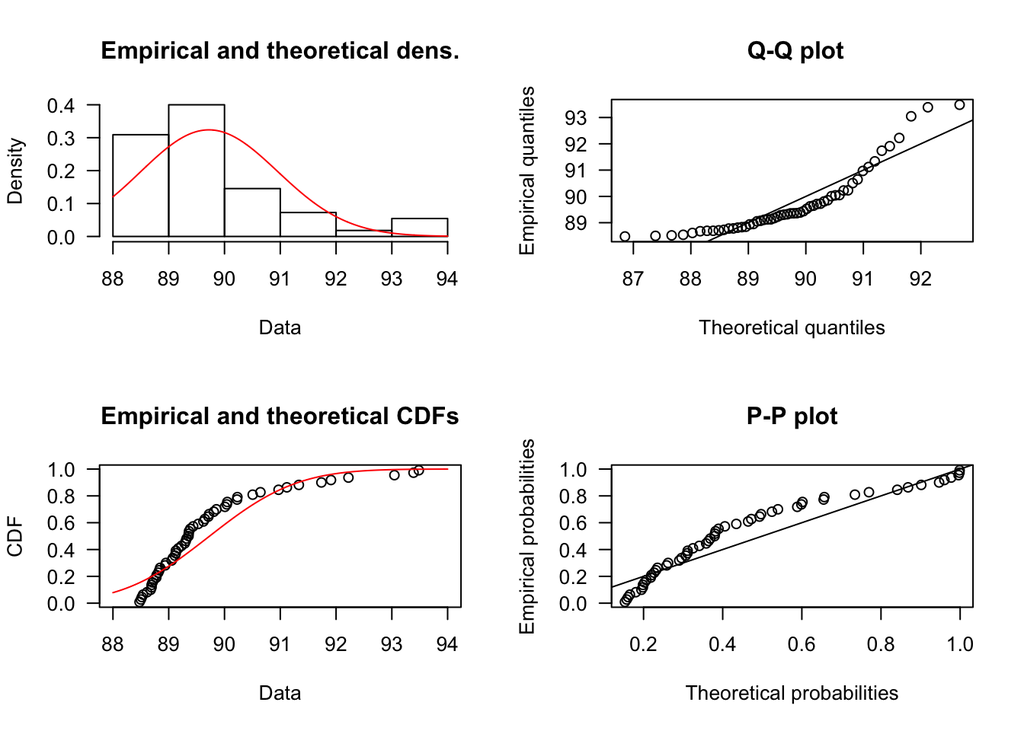

```r
plot(fitdistrplus::fitdist(filter(Event_C_joined_data, !is.na(time))$time, "gamma", method = "mme"), las = 1)
```

```r
summary(fitdistrplus::fitdist(filter(Event_C_joined_data, !is.na(time))$time, "gamma", method = "mme"), las = 1)
```

```
## Fitting of the distribution ' gamma ' by matching moments
## Parameters :
##         estimate
## shape 5304.11910
## rate    59.10667
## Loglikelihood:  -89.14204   AIC:  182.2841   BIC:  186.2987
```

## Event D

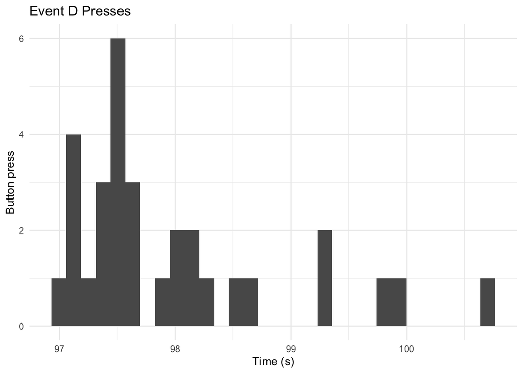

```r
Event_D <- tidy_data_filtered
Event_D[Event_D$time > 96.995 & Event_D$time < 102.996,]$seg <- "EventD"

Event_D$press <- 1

Event_D_joined_data <- left_join(my_df, select(Event_D,
                                               c("ID", "seg", "time", "press")), by = c("ID", "seg"))

Event_D_joined_data <- Event_D_joined_data %>%
  filter(seg == "EventD") %>%
  mutate(press = replace_na(press, 0))

Event_D %>%
  filter(seg == "EventD") %>%
  ggplot(aes(x = time)) +
  geom_histogram() +
  labs(title = "Event D Presses",
       x = "Time (s)",
       y = "Button press") +
  theme_minimal()
```

Let’s check the fit with the Gamma distribution and extract paaramenters using methods of moments estimation.

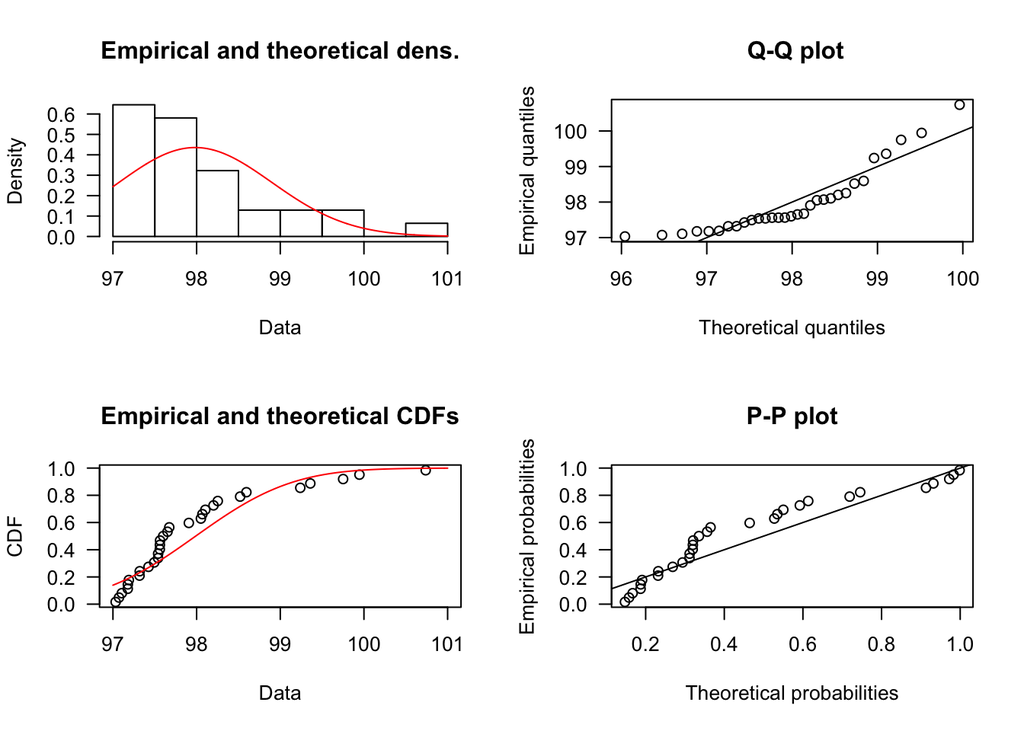

```r
plot(fitdistrplus::fitdist(filter(Event_D_joined_data, !is.na(time))$time, "gamma", method = "mme"), las = 1)
```

```r
summary(fitdistrplus::fitdist(filter(Event_D_joined_data, !is.na(time))$time, "gamma", method = "mme"), las = 1)
```

```
## Fitting of the distribution ' gamma ' by matching moments
## Parameters :
##         estimate
## shape 11450.4398
## rate    116.8515
## Loglikelihood:  -41.12606   AIC:  86.25211   BIC:  89.12009
```

Let’s work out the top quartile of responders for each of the Events A-D and examine whether the same participants are in the top quartile for each of the 4 events.

```r
Event_A_top_quartile <- Event_A_joined_data %>%
  filter(press == 1) %>%
  arrange(time) %>%
  top_frac(-.25, wt = time) %>%
  pull(ID) %>%
  cbind("A")

Event_B_top_quartile <- Event_B_joined_data %>%
  filter(press == 1) %>%
  arrange(time) %>%
  top_frac(-.25, wt = time) %>%
  pull(ID) %>%
  cbind("B")

Event_C_top_quartile <- Event_C_joined_data %>%
  filter(press == 1) %>%
  arrange(time) %>%
  top_frac(-.25, wt = time) %>%
  pull(ID) %>%
  cbind("C")

Event_D_top_quartile <- Event_D_joined_data %>%
  filter(press == 1) %>%
  arrange(time) %>%
  top_frac(-.25, wt = time) %>%
  pull(ID) %>%
  cbind("D")

rbind(Event_A_top_quartile,
  Event_B_top_quartile,
  Event_C_top_quartile,
  Event_D_top_quartile) %>%
  as_tibble(.name_repair = "minimal") %>%
  cbind(press = "1") %>%
  spread(key = Var.2, value = press) %>%
  mutate_all(funs(ifelse(is.na(.), 0, .))) %>%
  set_names("Participant", "Event_A_press", "Event_B_press", "Event_C_press", "Event_D_press")
```

```
##    Participant Event_A_press Event_B_press Event_C_press Event_D_press
## 1      B97-NWK             0             0             0             1
## 2      C08-YYP             0             1             0             0
## 3      C15-XTG             0             1             0             0
## 4      C35-PXR             0             0             0             1
## 5      D61-CVD             0             0             1             0
## 6      F35-PZT             0             0             1             1
## 7      F90-WKY             0             1             0             0
## 8      F91-CTG             1             1             0             0
## 9      G24-CWG             0             0             0             1
## 10     G97-KPM             0             0             0             1
## 11     H04-DKF             0             1             0             0
## 12     H12-BSD             1             0             0             0
## 13     K77-KFB             0             0             1             0
## 14     K94-MVV             0             0             1             0
```

[output cut: 28 more lines]

As we can see, most participants appear onlyin the top quartile for only one event - it’s not the case that the same people tend to respond quickly at each of the Event boundaries.